# Assignment5

Whytne Stevens

10/4/2020

For this assignment, I’m continuing my language and income analysis for Dallas County, Texas. I’m using my dataset that exactly denotes one’s household language. For my analysis, I’ll be focusing on the HHLANP_labelMarathi category for all the models I’m running below. Here, I’ve loaded relevant r libraries and my dataset as usual

```r
library(ggplot2)
library(tidycensus)
library(ggthemes)
library(tidyverse)
library(wesanderson)
library(viridis)
library(jtools)
library(interactions)
library(knitr)
```

```r
detailedlang <- read.csv("persondatalangdetail.csv") %>%
mutate(HHLANP_label = case_when(
    HHLANP_label=="English only household"~"1English only household",
    HHLANP_label=="Portuguese"~"Portuguese",
    HHLANP_label=="Other languages of Asia" ~ "Other languages of Asias",
    HHLANP_label=="Norwegian" ~ "Norwegian",
    HHLANP_label=="Spanish" ~ "Spanish",
    HHLANP_label=="Nepali"~"Nepali",
    HHLANP_label=="Mongolian" ~ "Mongolian",
    HHLANP_label=="Marathi" ~ "Marathi",
    HHLANP_label=="Mandarin" ~ "Mandarin",
    HHLANP_label=="Malayalam"~"Malayalam",
    HHLANP_label=="Khmer" ~ "Khmer",
    HHLANP_label=="Kannada" ~ "Kannada",
    HHLANP_label=="Igbo" ~ "Igbo",
    HHLANP_label=="Hungarian"~"Hungarian",
    HHLANP_label=="Hindi" ~ "Hindi",
    HHLANP_label=="Gujarati" ~ "Gujarati",
    HHLANP_label=="German" ~ "German",
    HHLANP_label=="French"~"French",
    HHLANP_label=="Farsi" ~ "Farsi",
    HHLANP_label=="Chinese" ~ "Chinese",
    HHLANP_label=="Bengali" ~ "Bengali",
    HHLANP_label=="Somali"~"Somali",
    HHLANP_label=="Swahili" ~ "Swahili",
    HHLANP_label=="Tagalog" ~ "Tagalog",
    HHLANP_label=="Tamil" ~ "Tamil",
    HHLANP_label=="Telugu"~"Telugu",
    HHLANP_label=="Thai" ~ "Thai",
    HHLANP_label=="Tigrinya" ~ "Tigrinya",
    HHLANP_label=="Urdu" ~ "Urdu",
    HHLANP_label=="Vietnamese" ~ "Vietnamese",
    HHLANP_label=="Yoruba" ~ "Yoruba",
    HHLANP_label=="Korean" ~ "Korean",
    HHLANP_label=="Amharic" ~ "Amharic",
    HHLANP_label=="Arabic" ~ "Arabic",
    HHLANP_label=="Burmese" ~ "Burmese",
    HHLANP_label=="Lao" ~ "Lao",
    HHLANP_label=="Other Mande languages" ~ "Other Mande languages",
    HHLANP_label=="Romanian" ~ "Romanian",
    HHLANP_label=="Russian" ~ "Russian"))
```

# Initial Regression Model for PINCP Variable using the Detailed Household Language (HHLANP) variable for my categorical variables and Results

```r
model5 <- lm(PINCP ~ HHLANP_label + WKHP + POVPIP,
            data = detailedlang)
options(scipen = 999)
summary(model5)
```

```
##
## Call:
## lm(formula = PINCP ~ HHLANP_label + WKHP + POVPIP, data = detailedlang)
##
## Residuals:
##    Min     1Q Median     3Q    Max
## -88779 -19551  -3482  10168 395715
##
## Coefficients:
##                                       Estimate Std. Error t value
## (Intercept)                          -28999.45    8213.42  -3.531
## HHLANP_labelAmharic                    7090.61   45159.03   0.157
## HHLANP_labelArabic                    -4623.12   31972.54  -0.145
## HHLANP_labelBengali                   15515.86   31905.83   0.486
## HHLANP_labelBurmese                  -10430.60   45129.66  -0.231
## HHLANP_labelChinese                  -16652.83   31927.00  -0.522
## HHLANP_labelFrench                      -20.65   20302.75  -0.001
## HHLANP_labelGujarati                 -29882.97   31946.85  -0.935
## HHLANP_labelHindi                     27386.73   26119.90   1.049
## HHLANP_labelIgbo                        153.50   20301.18   0.008
## HHLANP_labelKhmer                    -15906.29   31913.48  -0.498
## HHLANP_labelKorean                     7279.49   26097.81   0.279
## HHLANP_labelLao                      -22763.62   45073.09  -0.505
## HHLANP_labelMalayalam                -11571.49   20293.21  -0.570
## HHLANP_labelMandarin                   3419.61   31979.75   0.107
## HHLANP_labelMarathi                  395515.48   45072.77   8.775
## HHLANP_labelNepali                     7097.13   45269.52   0.157
## HHLANP_labelNorwegian                 -2877.07   45353.54  -0.063
## HHLANP_labelOther languages of Asias  -3556.63   45060.51  -0.079
## HHLANP_labelOther Mande languages     22529.88   45308.09   0.497
## HHLANP_labelPortuguese                 8494.41   45154.45   0.188
## HHLANP_labelRomanian                 -34066.61   45084.79  -0.756
## HHLANP_labelRussian                   29187.11   45204.47   0.646
## HHLANP_labelSpanish                   -5507.83    4276.03  -1.288
## HHLANP_labelSwahili                  -19117.36   45075.90  -0.424
## HHLANP_labelTagalog                   -1463.03   15209.24  -0.096
## HHLANP_labelTamil                     -9072.88   31984.47  -0.284
## HHLANP_labelTelugu                    14411.91   20278.97   0.711
## HHLANP_labelThai                     -28493.31   45054.81  -0.632
## HHLANP_labelUrdu                      35876.17   22658.44   1.583
```

[output cut: 30 more lines]

```
## HHLANP_labelTagalog                              0.923401
## HHLANP_labelTamil                                0.776771
## HHLANP_labelTelugu                               0.477576
## HHLANP_labelThai                                 0.527373
## HHLANP_labelUrdu                                 0.113905
## HHLANP_labelVietnamese                           0.339920
## HHLANP_labelYoruba                               0.946542
## WKHP                                            0.0000195 ***
## POVPIP                               < 0.0000000000000002 ***
## ---
## Signif. codes:  0 '***' 0.001 '**' 0.01 '*' 0.05 '.' 0.1 ' ' 1
##
## Residual standard error: 44980 on 562 degrees of freedom
## Multiple R-squared:  0.3352, Adjusted R-squared:  0.2962
## F-statistic: 8.588 on 33 and 562 DF,  p-value: < 0.00000000000000022
```

This is the original regression model I ran in assignment 4 for this dataset. To restate the results from the last assignment, the multiple R-squared value for this model is 0.3352, meaning that it predicts about 34% of this model. When controlled for ‘English only household,’ people whose household language is under the ‘Marathi’ category make about $396,000 more in income than those in the other HHLANP categories.

# Regression Model for PINCP Variable w/ log transformation for POVPIP variable, using the Detailed Household Language (HHLANP) variable for my categorical variables and Results

```r
model6 <- lm(PINCP ~ HHLANP_label + WKHP + log(POVPIP),
            data = detailedlang)

summary(model6)
```

```
##
## Call:
## lm(formula = PINCP ~ HHLANP_label + WKHP + log(POVPIP), data = detailedlang)
##
## Residuals:
##    Min     1Q Median     3Q    Max
## -87754 -21372  -7016  10500 405375
##
## Coefficients:
##                                       Estimate Std. Error t value
## (Intercept)                          -138897.1    19255.8  -7.213
## HHLANP_labelAmharic                    -5375.5    46407.4  -0.116
## HHLANP_labelArabic                       284.9    32964.8   0.009
## HHLANP_labelBengali                    12769.9    32823.8   0.389
## HHLANP_labelBurmese                   -23060.4    46382.4  -0.497
## HHLANP_labelChinese                   -13276.3    32839.4  -0.404
## HHLANP_labelFrench                     -6846.3    20872.0  -0.328
## HHLANP_labelGujarati                  -28317.9    32864.3  -0.862
## HHLANP_labelHindi                      30687.8    26864.4   1.142
## HHLANP_labelIgbo                       -3533.5    20880.6  -0.169
## HHLANP_labelKhmer                     -15254.0    32831.9  -0.465
## HHLANP_labelKorean                      2373.6    26843.5   0.088
## HHLANP_labelLao                       -33059.1    46348.5  -0.713
## HHLANP_labelMalayalam                 -10927.4    20876.7  -0.523
## HHLANP_labelMandarin                    -904.8    32892.8  -0.028
## HHLANP_labelMarathi                   400780.2    46359.3   8.645
## HHLANP_labelNepali                      3495.6    46606.1   0.075
## HHLANP_labelNorwegian                   2057.0    46650.3   0.044
## HHLANP_labelOther languages of Asias  -10242.7    46350.1  -0.221
## HHLANP_labelOther Mande languages      17367.7    46622.8   0.373
## HHLANP_labelPortuguese                  5675.6    46451.4   0.122
## HHLANP_labelRomanian                  -28857.0    46371.7  -0.622
## HHLANP_labelRussian                    34231.4    46495.6   0.736
## HHLANP_labelSpanish                   -11320.2     4286.1  -2.641
## HHLANP_labelSwahili                   -13874.7    46362.5  -0.299
## HHLANP_labelTagalog                    -3826.1    15645.7  -0.245
## HHLANP_labelTamil                      -4986.6    32896.1  -0.152
## HHLANP_labelTelugu                     16905.9    20860.1   0.810
## HHLANP_labelThai                      -27932.0    46351.4  -0.603
## HHLANP_labelUrdu                       36772.4    23312.1   1.577
```

[output cut: 30 more lines]

```
## HHLANP_labelTagalog                               0.80690
## HHLANP_labelTamil                                 0.87957
## HHLANP_labelTelugu                                0.41803
## HHLANP_labelThai                                  0.54701
## HHLANP_labelUrdu                                  0.11527
## HHLANP_labelVietnamese                            0.25199
## HHLANP_labelYoruba                                0.74973
## WKHP                                     0.00004785045037 ***
## log(POVPIP)                          < 0.0000000000000002 ***
## ---
## Signif. codes:  0 '***' 0.001 '**' 0.01 '*' 0.05 '.' 0.1 ' ' 1
##
## Residual standard error: 46270 on 562 degrees of freedom
## Multiple R-squared:  0.2964, Adjusted R-squared:  0.2551
## F-statistic: 7.176 on 33 and 562 DF,  p-value: < 0.00000000000000022
```

With this model the results differ somewhat from the initial model above. For example the multiple R-squared value for this model is 0.2964 (predicting about 30% of the model) while for the initial model it was 0.3352 (predicting about 34% of the model). For people whose household language is under the ‘Marathi’ category, this model shows that they make about $400,000 more in income than those in the other HHLANP categories, in comparison to the initial model where that number was 396,000.Therefore there’s only a 4,000 dollar difference in the models

# Regression Model for PINCP Variable w/ log transformation for WKHP variable, using the Detailed Household Language (HHLANP) variable for my categorical variables and Results

```r
model7 <- lm(PINCP ~ HHLANP_label + log(WKHP) + POVPIP,
            data = detailedlang)

summary(model7)
```

```
##
## Call:
## lm(formula = PINCP ~ HHLANP_label + log(WKHP) + POVPIP, data = detailedlang)
##
## Residuals:
##    Min     1Q Median     3Q    Max
## -90351 -19569  -3880  10091 396297
##
## Coefficients:
##                                       Estimate Std. Error t value
## (Intercept)                          -64084.32   15417.91  -4.156
## HHLANP_labelAmharic                    5575.99   45206.02   0.123
## HHLANP_labelArabic                    -5427.52   32007.20  -0.170
## HHLANP_labelBengali                   14061.55   31936.91   0.440
## HHLANP_labelBurmese                  -10557.43   45173.51  -0.234
## HHLANP_labelChinese                  -18082.86   31956.14  -0.566
## HHLANP_labelFrench                      530.76   20326.67   0.026
## HHLANP_labelGujarati                 -27999.73   31961.67  -0.876
## HHLANP_labelHindi                     25723.59   26141.34   0.984
## HHLANP_labelIgbo                      -2302.69   20304.27  -0.113
## HHLANP_labelKhmer                    -16658.21   31945.25  -0.521
## HHLANP_labelKorean                     6276.04   26125.86   0.240
## HHLANP_labelLao                      -24245.32   45117.85  -0.537
## HHLANP_labelMalayalam                -13527.68   20299.83  -0.666
## HHLANP_labelMandarin                   1908.40   31992.97   0.060
## HHLANP_labelMarathi                  394091.26   45114.16   8.735
## HHLANP_labelNepali                     3712.83   45300.80   0.082
## HHLANP_labelNorwegian                  -761.99   45473.76  -0.017
## HHLANP_labelOther languages of Asias  -3646.76   45103.61  -0.081
## HHLANP_labelOther Mande languages     19058.79   45317.95   0.421
## HHLANP_labelPortuguese                13681.88   45132.91   0.303
## HHLANP_labelRomanian                 -36592.50   45117.00  -0.811
## HHLANP_labelRussian                   26114.63   45202.87   0.578
## HHLANP_labelSpanish                   -6076.55    4278.86  -1.420
## HHLANP_labelSwahili                  -21019.01   45114.45  -0.466
## HHLANP_labelTagalog                   -2588.07   15225.55  -0.170
## HHLANP_labelTamil                    -11324.47   31990.14  -0.354
## HHLANP_labelTelugu                    13558.43   20301.09   0.668
## HHLANP_labelThai                     -29932.10   45097.00  -0.664
## HHLANP_labelUrdu                      33912.93   22668.70   1.496
```

[output cut: 30 more lines]

```
## HHLANP_labelTagalog                                 0.865
## HHLANP_labelTamil                                   0.723
## HHLANP_labelTelugu                                  0.504
## HHLANP_labelThai                                    0.507
## HHLANP_labelUrdu                                    0.135
## HHLANP_labelVietnamese                              0.326
## HHLANP_labelYoruba                                  0.895
## log(WKHP)                                       0.0000339 ***
## POVPIP                               < 0.0000000000000002 ***
## ---
## Signif. codes:  0 '***' 0.001 '**' 0.01 '*' 0.05 '.' 0.1 ' ' 1
##
## Residual standard error: 45020 on 562 degrees of freedom
## Multiple R-squared:  0.334,  Adjusted R-squared:  0.2949
## F-statistic:  8.54 on 33 and 562 DF,  p-value: < 0.00000000000000022
```

For this model, the multiple R-squared value is 0.334 (predicting about 33% of the model) while for the initial model it was 0.3352 (predicting about 34% of the model). For people whose household language is under the ‘Marathi’ category, this model shows that they make about $394,000 more in income than those in the other HHLANP categories, in comparison to the initial model where that number was 396,000.Therefore there’s only a 2,000 dollar difference in the models

# Regression Model for PINCP Variable w/ interaction items, using the Detailed Household Language (HHLANP) variable for my categorical variables and Results

```r
model8 <- lm(PINCP ~ HHLANP_label + WKHP + log(POVPIP) +
               log(POVPIP):HHLANP_label + HHLANP_label:WKHP +
               WKHP:log(POVPIP),
             data = detailedlang)

summary(model8)
```

```
##
## Call:
## lm(formula = PINCP ~ HHLANP_label + WKHP + log(POVPIP) + log(POVPIP):HHLANP_label +
##     HHLANP_label:WKHP + WKHP:log(POVPIP), data = detailedlang)
##
## Residuals:
##    Min     1Q Median     3Q    Max
## -68025 -18389  -4738   7345 401764
##
## Coefficients: (35 not defined because of singularities)
##                                                     Estimate  Std. Error
## (Intercept)                                         -13593.8     45928.2
## HHLANP_labelAmharic                                   1464.3     45640.7
## HHLANP_labelArabic                                  118013.3    140557.9
## HHLANP_labelBengali                                 200415.0    647511.3
## HHLANP_labelBurmese                                 -16972.8     45594.3
## HHLANP_labelChinese                               -4513175.3   4420169.0
## HHLANP_labelFrench                                   61598.8    499837.5
## HHLANP_labelGujarati                              -1472566.4   7848943.5
## HHLANP_labelHindi                                 -2466448.1   2353853.5
## HHLANP_labelIgbo                                   -112633.7    414762.3
## HHLANP_labelKhmer                                   334791.3   1547621.9
## HHLANP_labelKorean                                 -362249.6    830310.4
## HHLANP_labelLao                                     -30556.9     45526.3
## HHLANP_labelMalayalam                               -60307.0    325895.2
## HHLANP_labelMandarin                               -305064.1    320595.1
## HHLANP_labelMarathi                                 398923.8     45543.5
## HHLANP_labelNepali                                    6154.1     45995.4
## HHLANP_labelNorwegian                                12026.5     46136.3
## HHLANP_labelOther languages of Asias                 -9889.4     45526.2
## HHLANP_labelOther Mande languages                    12343.2     46088.3
## HHLANP_labelPortuguese                                1000.1     45711.8
## HHLANP_labelRomanian                                -28742.4     45565.7
## HHLANP_labelRussian                                  40258.9     45816.8
## HHLANP_labelSpanish                                  39489.8     38118.9
## HHLANP_labelSwahili                                 -14942.7     45548.6
## HHLANP_labelTagalog                                 -46103.4    299110.3
## HHLANP_labelTamil                                -10599430.6   8127903.1
## HHLANP_labelTelugu                                  302817.6    255639.5
## HHLANP_labelThai                                    -28890.6     45529.1
```

[output cut: 255 more lines]

```
## HHLANP_labelSwahili:WKHP
## HHLANP_labelTagalog:WKHP
## HHLANP_labelTamil:WKHP
## HHLANP_labelTelugu:WKHP                          *
## HHLANP_labelThai:WKHP
## HHLANP_labelUrdu:WKHP                            **
## HHLANP_labelVietnamese:WKHP
## HHLANP_labelYoruba:WKHP
## WKHP:log(POVPIP)                                 ***
## ---
## Signif. codes:  0 '***' 0.001 '**' 0.01 '*' 0.05 '.' 0.1 ' ' 1
##
## Residual standard error: 45440 on 534 degrees of freedom
## Multiple R-squared:  0.3552, Adjusted R-squared:  0.2815
## F-statistic: 4.822 on 61 and 534 DF,  p-value: < 0.00000000000000022
```

For this model, the multiple R-squared value is 0.3552 (predicting about 36% of the model) while for the initial model it was 0.3352 (predicting about 34% of the model). For people whose household language is under the ‘Marathi’ category, this model shows that they make about $399,000 more in income than those in the other HHLANP categories, in comparison to the initial model where that number was 396,000.Therefore there’s only a 3,000 dollar difference in the models

# Model fit for Models 5-8 and Results

After running these models, I then plotted them below to see which one had the best fit for my dataset:

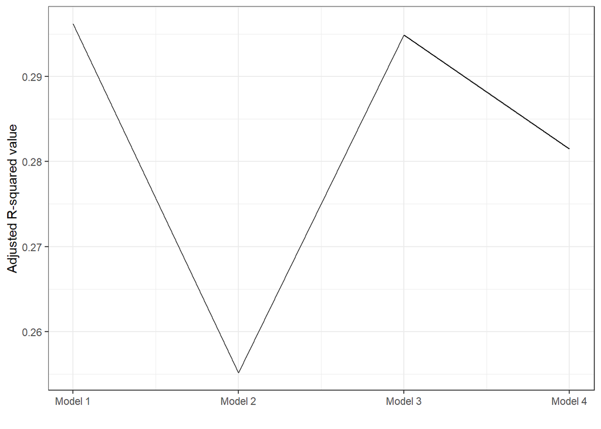

```r
ModelFit2 <- tibble(model = c(1, 2, 3, 4),
                   R_square = c(summary(model5)$adj.r.squared,
                                summary(model6)$adj.r.squared,
                                summary(model7)$adj.r.squared,
                                summary(model8)$adj.r.squared))

ggplot(ModelFit2, aes(x = model, y = R_square)) +
  geom_line() +
  scale_x_continuous(name = "",
                   breaks = breaks <- seq(1, 4, by = 1),
                   labels = paste("Model", breaks)) +
  scale_y_continuous(name = "Adjusted R-squared value") +
  theme_bw()
```

Based on the chart above it seems that my initial model was the best fit. I’ve also put the result in a table below. Since my initial model is the preferred model, I though it would be interesting to also compare it with second best fitting model, Model 7

```r
coeff_names2 <- c("Weekly work hours" = "WKHP",
                 "Income to Poverty Ratio" = "POVPIP",
                 "Houshold language is Marathi(compared to other categories of detailed household languages)" =
                   "HHLANP_labelMarathi")

export_summs(model5, model5, model7,
             error_format = "(p = {p.value})",
             error_pos = "same",
             model.names = c("Initial model", "Preferred model", "Second Best Model"),
             coefs = coeff_names2)
```

|  | Initial model | Preferred model | Second Best Model |
| --- | --- | --- | --- |
| Weekly work hours | 683.58 *** (p = 0.00) | 683.58 *** (p = 0.00) |  |
| Income to Poverty Ratio | 147.99 *** (p = 0.00) | 147.99 *** (p = 0.00) | 147.72 *** (p = 0.00) |
| Houshold language is Marathi(compared to other categories of detailed household languages) | 395515.48 *** (p = 0.00) | 395515.48 *** (p = 0.00) | 394091.26 *** (p = 0.00) |
| N | 596 | 596 | 596 |
| R2 | 0.34 | 0.34 | 0.33 |
| *** p < 0.001; ** p < 0.01; * p < 0.05. |  |  |  |

And finally, I created charts for both model5 and model7 to show the effect the Marathi category had on predicted income for the people included in my dataset

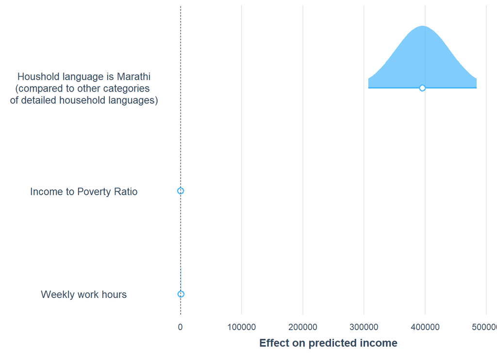

```r
coeff_desc <- c("Weekly work hours" = "WKHP",
                 "Income to Poverty Ratio" = "POVPIP",
                 "Houshold language is Marathi\n(compared to other categories \nof detailed household languages)" =
                   "HHLANP_labelMarathi")

plot_coefs(model5,
           coefs = coeff_desc,
           plot.distributions = TRUE,
           rescale.distributions = TRUE) +
  scale_x_continuous(name = "Effect on predicted income")
```

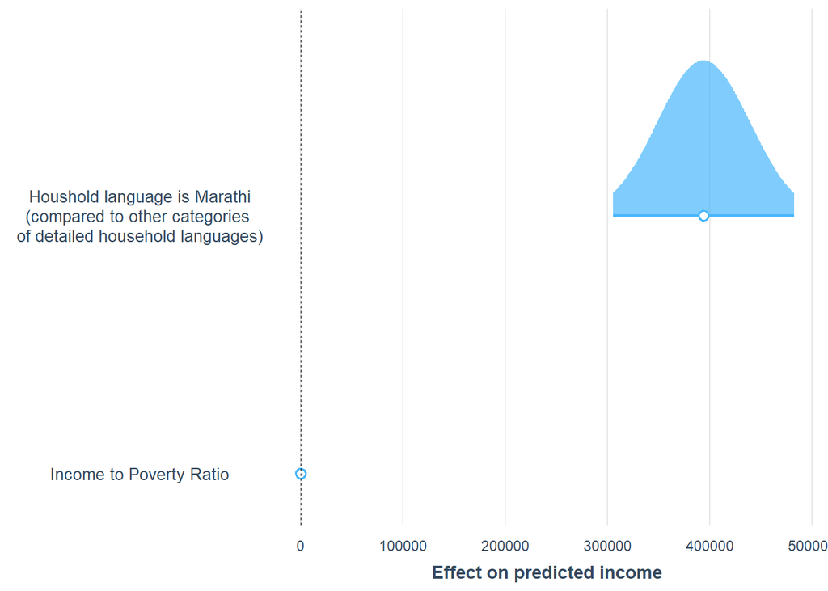

```r
coeff_desc <- c("Weekly work hours" = "WKHP",
                 "Income to Poverty Ratio" = "POVPIP",
                 "Houshold language is Marathi\n(compared to other categories \nof detailed household languages)" =
                   "HHLANP_labelMarathi")

plot_coefs(model7,
           coefs = coeff_desc,
           plot.distributions = TRUE,
           rescale.distributions = TRUE) +
  scale_x_continuous(name = "Effect on predicted income")
```